# Problem Set 1, due January 13th at 12:00pm

(in other words, it is due at noon, or one minute after 11:59am).

### Before You Start

Make sure to at least take a basic tutorial in the IPython notebook, otherwise you'll be totally lost. For this problem set, you should download INFX574-PS1.ipynb and the flights.zip dataset from Canvas. Create a local copy of the notebook and rename it LASTNAME_FIRSTNAME-PS1.ipynb. Then edit your renamed file directly in your browser by typing:

```
ipython notebook <name_of_downloaded_file>
```

You should also make sure the following libraries load correctly (click on the box below and hit Ctrl-Enter)

```python
print 'Pierre Augustamar'
print 'January 17'
print 'INFX 574 A'
print 'Problem Se1 1'
```

```
Pierre Augustamar
January 17
INFX 574 A
Problem Se1 1
```

```python
#IPython is what you are using now to run the notebook
import IPython
print "IPython version:      %6.6s (need at least 1.0)" % IPython.__version__

# Numpy is a library for working with Arrays
import numpy as np
print "Numpy version:        %6.6s (need at least 1.7.1)" % np.__version__

# SciPy implements many different numerical algorithms
import scipy as sp
print "SciPy version:        %6.6s (need at least 0.12.0)" % sp.__version__

# Pandas makes working with data tables easier
import pandas as pd
print "Pandas version:       %6.6s (need at least 0.11.0)" % pd.__version__

# Module for plotting
import matplotlib
print "Mapltolib version:    %6.6s (need at least 1.2.1)" % matplotlib.__version__

# SciKit Learn implements several Machine Learning algorithms
import sklearn
print "Scikit-Learn version: %6.6s (need at least 0.13.1)" % sklearn.__version__
```

```
IPython version:       5.1.0 (need at least 1.0)
Numpy version:        1.11.3 (need at least 1.7.1)
SciPy version:        0.18.1 (need at least 0.12.0)
Pandas version:       0.19.2 (need at least 0.11.0)
Mapltolib version:     1.5.3 (need at least 1.2.1)
Scikit-Learn version: 0.18.1 (need at least 0.13.1)
```

## About the Problem Set:

This is the same problem set used by Emma Spiro in INFX573. The only difference is that instead of doing the problem set in R, you will use Python and the IPython notebook.

## Instructions:

In this problem set you will perform a basic exploratory analysis on an example dataset, bringing to bear all of your new skills in data manipulation and visualization. You will be required to submit well commented python code, documenting all code used in this problem set, along with a write up answering all questions below. Use figures as appropriate to support your answers, and when required by the problem. This data set uses the NYCFlights13 dataset. You can download the dataset from canvas.

```python
import pandas as pd
import numpy as np
import matplotlib.pyplot as plt
```

```python
flights_df= pd.read_csv('flights.csv')
```

```python
print flights_df.shape
print flights_df.columns
print flights_df.dtypes
```

```
(336776, 17)
Index([u'Unnamed: 0', u'year', u'month', u'day', u'dep_time', u'dep_delay',
       u'arr_time', u'arr_delay', u'carrier', u'tailnum', u'flight', u'origin',
       u'dest', u'air_time', u'distance', u'hour', u'minute'],
      dtype='object')
Unnamed: 0      int64
year            int64
month           int64
day             int64
dep_time      float64
dep_delay     float64
arr_time      float64
arr_delay     float64
carrier        object
tailnum        object
flight          int64
origin         object
dest           object
air_time      float64
distance        int64
hour          float64
minute        float64
dtype: object
```

```python
flights_df.dest.unique()
flights_df.head(10)
```

|  | Unnamed: 0 | year | month | day | dep_time | dep_delay | arr_time | arr_delay | carrier | tailnum | flight | origin | dest | air_time | distance | hour | minute |
| --- | --- | --- | --- | --- | --- | --- | --- | --- | --- | --- | --- | --- | --- | --- | --- | --- | --- |
| 0 | 1 | 2013 | 1 | 1 | 517.0 | 2.0 | 830.0 | 11.0 | UA | N14228 | 1545 | EWR | IAH | 227.0 | 1400 | 5.0 | 17.0 |
| 1 | 2 | 2013 | 1 | 1 | 533.0 | 4.0 | 850.0 | 20.0 | UA | N24211 | 1714 | LGA | IAH | 227.0 | 1416 | 5.0 | 33.0 |
| 2 | 3 | 2013 | 1 | 1 | 542.0 | 2.0 | 923.0 | 33.0 | AA | N619AA | 1141 | JFK | MIA | 160.0 | 1089 | 5.0 | 42.0 |
| 3 | 4 | 2013 | 1 | 1 | 544.0 | -1.0 | 1004.0 | -18.0 | B6 | N804JB | 725 | JFK | BQN | 183.0 | 1576 | 5.0 | 44.0 |
| 4 | 5 | 2013 | 1 | 1 | 554.0 | -6.0 | 812.0 | -25.0 | DL | N668DN | 461 | LGA | ATL | 116.0 | 762 | 5.0 | 54.0 |
| 5 | 6 | 2013 | 1 | 1 | 554.0 | -4.0 | 740.0 | 12.0 | UA | N39463 | 1696 | EWR | ORD | 150.0 | 719 | 5.0 | 54.0 |
| 6 | 7 | 2013 | 1 | 1 | 555.0 | -5.0 | 913.0 | 19.0 | B6 | N516JB | 507 | EWR | FLL | 158.0 | 1065 | 5.0 | 55.0 |
| 7 | 8 | 2013 | 1 | 1 | 557.0 | -3.0 | 709.0 | -14.0 | EV | N829AS | 5708 | LGA | IAD | 53.0 | 229 | 5.0 | 57.0 |
| 8 | 9 | 2013 | 1 | 1 | 557.0 | -3.0 | 838.0 | -8.0 | B6 | N593JB | 79 | JFK | MCO | 140.0 | 944 | 5.0 | 57.0 |
| 9 | 10 | 2013 | 1 | 1 | 558.0 | -2.0 | 753.0 | 8.0 | AA | N3ALAA | 301 | LGA | ORD | 138.0 | 733 | 5.0 | 58.0 |

## Some Tips

- This assignment involves extensive Data frame splitting and aggregation. You should look into the details of the methods groupby, transform, sum, count, mean etc
- Many of the tasks in the assignment can be done either through the Pandas Data Frame or by converting the data frames to Series. Many of the methods in the numpy are applicable to Series only. When stuck, try to explore the type of object (Pandas Data Frame or Numpy Series) you are dealing with.

## Question 1

Let’s explore flights from NYC to Seattle. Use the flights dataset to answer the following questions.

2(a) How many flights were there from NYC airports to Seattle in 2013?

```python
#usin the len function to query flights traveling to Seattle from NYC
sea_flights = len(flights_df.query('dest=="SEA"'))

print "There were %d flights from NYC to Seattle." % sea_flights
```

```
There were 3923 flights from NYC to Seattle.
```

-- Write your answer in English here --

(b) How many airlines fly from NYC to Seattle?

```python
#use the len function to get total unique carrier to Seattle
airlines_fly_to_Seattle = len(flights_df.query('dest=="SEA"').carrier.unique())

print "There are %d airlines that fly from NYC to Seattle." % airlines_fly_to_Seattle
```

```
There are 5 airlines that fly from NYC to Seattle.
```

-- Write your answer in English here --

(c) How many unique air planes fly from NYC to Seattle?

```python
#use len to find total unique tailnum for flights going to Seattle
unique_airplanes_to_Seattle = len(flights_df.query('dest=="SEA"').tailnum.unique())

print "There were %d unique air planes that fly from NYC to Seattle." % unique_airplanes_to_Seattle
```

```
There were 936 unique air planes that fly from NYC to Seattle.
```

-- Write your answer in English here --

(d) What is the average arrival delay for flights from NC to Seattle?

```python
# get records that contains fligths from NYC to SEA
sea_flights = flights_df.query('dest=="SEA"')

# remove records that contain arrival delay equals to NA
sea_flights_finite = sea_flights[np.isfinite(sea_flights['arr_delay'])]

#calculate average arrival delay
average_arrival_delay_NYCToSEA = sea_flights_finite["arr_delay"].mean()

#format the response based on whether the average arrival delay is positive or negative
if average_arrival_delay_NYCToSEA > 0:
    print "On average flights from NYC to SEA were late by %.2f minutes." % average_arrival_delay_NYCToSEA
else:
    average_arrival_delay_NYCToSEA = average_arrival_delay_NYCToSEA * -1
    print "On average flights from NYC to SEA were early by %.2f minutes." % average_arrival_delay_NYCToSEA
```

```
On average flights from NYC to SEA were early by 1.10 minutes.
```

-- Write your answer in English here --

(e) What proportion of flights to Seattle come from each NYC airport?

```python
#function to calculate proportion
def proportion(origin):
    total_flights=len(flights_df.query('dest=="SEA"'))*1.0
    # get flights goiing to Seattle based on the NYC airport
    flights_by_origin=flights_df[(flights_df['dest']=="SEA") & (flights_df['origin']==origin)]
    total_flights_by_origin = len(flights_by_origin)*1.0 # convert to float
    proportion = (total_flights_by_origin/total_flights) #calculate the proportion
    proportion = np.round(proportion, decimals=2) #round it to 2 decimal points
    return int(proportion* 100)

#find the origin that flights to seattle start from in NYC
unique_NYC_airports_to_Seattle = flights_df.query('dest=="SEA"').origin.unique()

#loop through the unique airports and calculate the proportion
for airport in unique_NYC_airports_to_Seattle:
    pro=proportion(airport)
    print 'The proportion of fligths to Seattle from %s is %d percent' % (airport, pro)
```

```
The proportion of fligths to Seattle from EWR is 47 percent
The proportion of fligths to Seattle from JFK is 53 percent
```

-- Write your answer in English here --

## Question 2

Flights are often delayed. Consider the following questions exploring delay patterns.

(a) Which date has the largest average departure delay? Which date has the largest average arrival delay?

```python
#option 1
def findDateWithHighestAverageDelay(delayType):
    maxAvgDelay = 0
    dateMonth = 0
    dateDay = 0
    unique_month=flights_df.month.unique()
    #loop through the month and day and calculate the average delay = mean of departure delay or mean of arrival delay
    for m in unique_month:
        for d in range(1,31):
            current_date = flights_df.loc[(flights_df['month'] == m) & flights_df['day']==d]
            if delayType == 'arr_delay':
                postiveArrivalDelay = current_date.query('arr_delay > 0')
                average_arrival =  postiveArrivalDelay.arr_delay.mean()
            else:
                positiveDepartureDelay = current_date.query('dep_delay > 0')
                average_arrival = positiveDepartureDelay.dep_delay.mean()
            if np.isnan(average_arrival):
                continue
            if maxAvgDelay < average_arrival:
                maxAvgDelay = average_arrival #track the highest delay
                dateMonth = m #track the month
                dateDay = d    #track the day

    if delayType=="arr_delay":
        print "%s/%s had the largest average arrival delay of %.2f minutes from flights leaving NYC in 2013." % (dateMonth, dateDay, maxAvgDelay)
    else:
        print "%s/%s had the highest average departure delay of %.2f minutes from flights leaving NYC in 2013." % (dateMonth, dateDay, maxAvgDelay)


#function to get date with highest arrival delays
findDateWithHighestAverageDelay("arr_delay")
findDateWithHighestAverageDelay("dep_delay")
print

#option 2
#using groupby and lambda to get the average
grouped1 = flights_df.query('dep_delay > 0').groupby(['month', 'day']).apply(lambda x: np.average(x['dep_delay']))
x = grouped1.sort_values() #sort the record
x.tail(1) #take the top result from a descending order

print 'Second option shows that the largest average depature was on 9/2 with a delay of 116 minutes'
grouped2 = flights_df.query('arr_delay > 0').groupby(['month', 'day']).apply(lambda x: np.average(x['arr_delay']))
y = grouped2.sort_values() #sort the record
y.tail(1) #take the top result from a descending order

print 'Second option shows that the largest average arrival was on 9/12 with a delay of 127.86 minutes'
print
```

[output not shown]

-- Write your answer in English here --

(b) What was the worst day to fly out of NYC in 2013 if you dislike delayed flights?

```python
#worst day to fly out will be a combination of positive departure delay and arrival delay
maxDelay = 0
badDay = 0
badMonth = 0
unique_month=flights_df.month.unique() #find unique month
for m in unique_month:   #loop through the month and day
    for d in range(1,31):
        current_date = flights_df.loc[(flights_df['month'] == m) & flights_df['day']==d]
        positiveDepartureDelay = current_date.query('dep_delay > 0') #retrieve only positve entries
        departDelay = positiveDepartureDelay.dep_delay.mean() #calculate the mean
        postiveArrivalDelay = current_date.query('arr_delay > 0')
        arrivalDelay =  postiveArrivalDelay.arr_delay.mean()
        if (np.isnan(departDelay)): #remove any na values
            continue
        totalDelay = departDelay + arrivalDelay
        if totalDelay > maxDelay:
            maxDelay =  totalDelay #keep track of the highest delay and the date
            badDay = d
            badMonth = m

print 'The worst day to fly out of NYC in 2013 appears to be on %s/%s. It had an average delay of arrival and departure of %.2f minutes.' %(badMonth, badDay, maxDelay)

print
#option 2
#using groupby and lambda to calculate the average
grouped1 = flights_df.query('dep_delay > 0').groupby(['month', 'day']).apply(lambda x: np.average(x['dep_delay']))
x = grouped1.sort_values() #sort the result
grouped2 = flights_df.query('arr_delay > 0').groupby(['month', 'day']).apply(lambda x: np.average(x['arr_delay']))
y = grouped2.sort_values() #sor the result

#create a new dataframe that's a combination of the first two created
newset = pd.DataFrame({'dep_delay' : x, 'arr_delay': y}).reset_index()

#add a column to hold the total delay of arrival and departure
newset['total_avg_delay'] = newset['arr_delay'] + newset['dep_delay']
x = newset.sort_values(['total_avg_delay'], ascending=[0]) #sort the result
print x.head(1) # take the top first result
print
print "Second option shows that the worst day to fly out is 9/12 as it has a delay of 239 minutes total average of arrival and departure delay time"
```

[output not shown]

-- Write your answer in English here --

(c) Are there any seasonal patterns in departure delays for flights from NYC?

```python
#calculate delays by month
import calendar
result ={}
unique_month=flights_df.month.unique() #get unique month of the data set
for m in unique_month:
        current_date = flights_df.loc[(flights_df['month'] == m)] #get current date based on the month
        departDelay = current_date.dep_delay.mean() #generate a mean by month
        if (np.isnan(departDelay)): #remove any na values
            continue
        result[m] = departDelay #store the result into a dictionary of key month and value the departDelay

sorted(result)
for k, v in result.items():
	    print '%s-2013 delay was at %.2f minutes' % (calendar.month_name[k], v)

print
print 'The data shows a peak of high average departure delay in June and July then decrease'


#option 2
#using groupby and lambad to calculate the average
grouped3 = flights_df.groupby(['month']).apply(lambda x: np.average(x['dep_delay']))
newset4 = grouped3.sort_values(ascending=1) #order the result in descending order
```

```
January-2013 delay was at 10.04 minutes
February-2013 delay was at 10.82 minutes
March-2013 delay was at 13.23 minutes
April-2013 delay was at 13.94 minutes
May-2013 delay was at 12.99 minutes
June-2013 delay was at 20.85 minutes
July-2013 delay was at 21.73 minutes
August-2013 delay was at 12.61 minutes
September-2013 delay was at 6.72 minutes
October-2013 delay was at 6.24 minutes
November-2013 delay was at 5.44 minutes
December-2013 delay was at 16.58 minutes

The data shows a peak of high average departure delay in June and July then decrease
```

-- Write your answer in English here --

(d) On average, how do departure delays vary over the course of a day?

```python
result= {} #dictionarry to add result
#calculate average delays per hour
unique_hour = flights_df.hour.unique() #get unique hours from the dataset
for h in unique_hour: #iterate through the list of hours
    current_hour = flights_df.loc[(flights_df['hour'] == h)] #get the actual data set for that horu
    current_hour = current_hour[np.isfinite(current_hour['hour'])] #remove any na data
    result[h] = current_hour.dep_delay.mean() #calculate the average departure for that hour

for k, v in result.items():
	    print 'At hour %s delay was at %.2f' % (k, v)
print
print 'The data shows that on average there are minimal delays from hour 7 to hour 11 of the day. However, there are significant delays early mornings mainly from hour 0 to hour 3'

print

#option 2
#using groupby and lambad to calculate the average of the departure
grouped1 = flights_df.groupby(['hour']).apply(lambda x: np.average(x['dep_delay']))
newset2 = grouped1.sort_values(ascending=1) #order the result in descending order
print "option 2"
newset2
```

[output not shown]

```
hour
4.0      -5.554098
5.0      -4.355644
6.0      -1.520552
7.0       0.223289
8.0       1.091432
9.0       4.268295
10.0      5.548644
11.0      5.652309
12.0      7.601892
14.0      8.090381
13.0      9.380639
15.0     10.682049
16.0     13.621150
17.0     16.756593
18.0     18.664671
19.0     21.497342
20.0     28.266213
21.0     42.064964
22.0     68.190042
23.0     96.616196
1.0     207.049327
2.0     239.921875
3.0     304.727273
dtype: float64
```

-- Write your answer in English here --

## Question 3

```
Which flight departing NYC in 2013 flew the fastest?
```

```python
#Assuming fastest is defined by the length of time on the air then this would be the longest distance with the shortest air time

#function to find the longest route
longest_distance= flights_df.distance.max()

#query flights including air time for the longest distance
flights_with_longest_distance = flights_df.query('distance==%d' % longest_distance)

#find air time for flights with the longest route
lowest_air_time = flights_with_longest_distance.air_time.min()

#query flights with longest route that has the shortest air time
flights = flights_df.query('air_time==%d' % lowest_air_time)
flights = flights.where(flights_df['distance']==longest_distance)

#remove NA records from the data set
flights_finite = flights[np.isfinite(flights['distance'])]

current_flight=70.0 #bogus flight for initialization
for index, row in flights_finite.iterrows():
    if current_flight == row['flight']:
        continue # go to the next entry
    else:
        current_flight = row['flight']
        print "Flight number %.1f from %s to %s flew a distance of %.1f and spent %.1f mintues in the air. Thus, the fastest flight." % (row['flight'], row['origin'], row['dest'], row['distance'], row['air_time'])
```

```
Flight number 51.0 from JFK to HNL flew a distance of 4983.0 and spent 580.0 mintues in the air. Thus, the fastest flight.
```

-- Write your answer in English here --

Question 4 Which flights (i.e. carrier + flight + dest) happen every day? Where do they fly to?

```python
# function to format result
def formatResult(flight, destAndCarrier):
    v = destAndCarrier.split("_") #split carrir from destination
    dest = v[0]
    carrier= v[1]
    print "flight %s travelled daily from NYC to %s using carrier %s ." % (flight, dest, carrier)

# function to load flights that travelled daily
def getDestinationAndCarriersThatMakeYearlyTrips(flights):
    unique_destinations = flights_df.dest.unique() #get unique destinations
    unique_carriers= flights_df.carrier.unique() #get unique carriers

    daily_flight ={}  #create a dictionary to hold data
    for carrier in unique_carriers: #iterate by the carriers
        for dest in unique_destinations: # get a destination
            #get a data set based on the carrier and the destination
            flights =  flights_df.loc[(flights_df["dest"] == dest) & (flights_df["carrier"] == carrier)]
            total =  len(flights) #get total flights
            #only capture data where the total is equal to 365
            if total == 365: #todo update in case year has has 364 days - but 2013 has 365
                key = dest+'_'+carrier #create a key forms using dest and carrier
                daily_flight[key] = flights.flight.unique().tolist() #add the unique fligth with the key

    return daily_flight

# get all the carriers and destinations that have a daily trip
daily_flight = getDestinationAndCarriersThatMakeYearlyTrips(flights_df)

#print unique flights that make daily trips
for l in daily_flight:
    if len(daily_flight[l])==1: #only select the entries that have a unique flights
        formatResult(daily_flight[l][0], l)
```

```
flight 15 travelled daily from NYC to HNL using carrier UA .
flight 251 travelled daily from NYC to LAS using carrier VX .
```

-- Write your answer in English here --

## Question 5

Develop one research question you can address using the nycflights2013 dataset. Provide two visualizations to support your exploration of this question. Discuss what you find.

```
research question is to find destinations that averaged over 20 minutes of delays
```

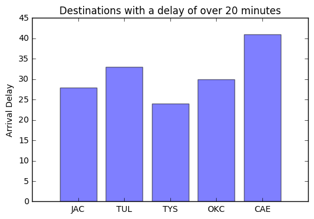

```
The graph shows that there were 5 destinations that have an arrival delay that's over 20 minutes.
It also shows that all of the destinations are from smaller markets that are predominantly in the South
```

```python
print "research question is to find destinations that averaged over 20 minutes of delays"

#global variables
objects = []
performance = []

# function to get records that contain fligths from NYC to SEA
def findDestinationsWithOver20MinutesArrivalDelay():
    unique_destinations = flights_df.dest.unique()
    for dest in unique_destinations:
        current_flights = flights_df.loc[(flights_df['dest'] == dest)]
        average_arrival = current_flights["arr_delay"].mean()
        if average_arrival > 21: # delay greater than 20 minutes
            objects.append(dest)
            performance.append(int(average_arrival))


#function to plot the bar graphs representing the delayed destinations
def plotArrivalDelayedDestination():
    y_pos = np.arange(len(objects))
    plt.bar(y_pos, performance, align='center', alpha=0.5)
    plt.xticks(y_pos, objects)
    plt.ylabel('Arrival Delay')
    plt.title('Destinations with a delay of over 20 minutes')
    plt.show()

#call the functions to build the graph and collect the data
findDestinationsWithOver20MinutesArrivalDelay()
plotArrivalDelayedDestination()

print "The graph shows that there were 5 destinations that have an arrival delay that's over 20 minutes."
print "It also shows that all of the destinations are from smaller markets that are predominantly in the South"
```

-- Enter your discussion here --

## Question 6

What weather conditions are associated with flight delays leaving NYC? Use graphics to explore.

[figure not shown]

[output not shown]

```python
#global variables
performance = []
temperature = []

#import weather file
weather_df=pd.read_csv('weather.csv')
#analyze data
weather_df.head(5)
weather_df.hour.unique()

#update flight hour column in order to match with weather data
flights_df['hour'].replace([24,0],inplace=True)

#joining flights and weather datasets
flights_weather = pd.concat([flights_df, weather_df], axis=1, join_axes=[flights_df.index])
#add a column to hold the total delay
sLength = len(flights_weather['visib'])
flights_weather.loc[:,'totaldelay'] = pd.Series(np.random.randn(sLength), index=flights_weather.index)

#remonve data that contain NA from the generated graph
flights_weather = flights_weather[np.isfinite(flights_weather['temp'])]
flights_weather = flights_weather[np.isfinite(flights_weather['arr_delay'])]
flights_weather = flights_weather[np.isfinite(flights_weather['dep_delay'])]

# calculate delays for positive arrival delays and departure delays
for index, row in flights_weather.iterrows():
    row['totaldelay'] = 0
    if row['dep_delay'] < 0:
        row['dep_delay'] = 0
    if row['arr_delay'] < 0:
        row['arr_delay'] = 0
    row['totaldelay'] = row['dep_delay'] + row['arr_delay']
    temperature.append(row['temp']) #store the temperature for that delay into a list
    performance.append(int(row['totaldelay'])) #store the actual delay


#function to plot total delays vs a specific weather
def plotTotalDelayInRelationToWeather(weather, objects):
    y_pos = np.arange(len(objects))
    plt.bar(y_pos, performance, align='center', alpha=0.5)
    plt.xticks(y_pos, objects)
    plt.ylabel('Total Delay')
    plt.title('Total delay vs  %s' % weather)
    plt.xlabel(weather)
    plt.show()

#call teh plot function
plotTotalDelayInRelationToWeather('temp', temperature)



print "The graph related to temperature vs total delays shows a spike on the total delays when the temperature rises"
```

-- Enter your interpretation here --